# featuretoolsR demo

# Goal

Understand how featuretoolsR, the R implementation of Featuretools ([Python documentation](https://docs.featuretools.com/)) can be used with relational data to reproducibly create derived features. I expect the package can create more features and do it with greater efficiency compared to subquerying/aggregating in SQL.

```r
library(tidyverse)
library(lubridate)
library(wranglR)
library(readxl)
library(foreach)
library(reticulate)
library(featuretoolsR)
```

# Toy data

A small dataset for testing and understanding how some of the transformations work. Taken from the article [Automated Feature Engineering in Python](https://towardsdatascience.com/automated-feature-engineering-in-python-99baf11cc219).

```r
clients <- read_csv(file = 'data/demo/clients.csv')
loans <- read_csv(file = 'data/demo/loans.csv')
payments <- read_csv(file = 'data/demo/payments.csv')
```

```r
str(clients)
```

```
Classes ‘spec_tbl_df’, ‘tbl_df’, ‘tbl’ and 'data.frame':    25 obs. of  4 variables:
 $ client_id   : num  46109 49545 41480 46180 25707 ...
 $ joined      : Date, format: "2002-04-16" "2007-11-14" "2013-03-11" "2001-11-06" ...
 $ income      : num  172677 104564 122607 43851 211422 ...
 $ credit_score: num  527 770 585 562 621 610 730 771 696 769 ...
 - attr(*, "spec")=
  .. cols(
  ..   client_id = col_double(),
  ..   joined = col_date(format = ""),
  ..   income = col_double(),
  ..   credit_score = col_double()
  .. )
```

```r
str(loans)
```

```
Classes ‘spec_tbl_df’, ‘tbl_df’, ‘tbl’ and 'data.frame':    443 obs. of  8 variables:
 $ client_id  : num  46109 46109 46109 46109 46109 ...
 $ loan_type  : chr  "home" "credit" "home" "cash" ...
 $ loan_amount: num  13672 9794 12734 12518 14049 ...
 $ repaid     : num  0 0 1 1 1 0 1 0 1 1 ...
 $ loan_id    : num  10243 10984 10990 10596 11415 ...
 $ loan_start : Date, format: "2002-04-16" "2003-10-21" "2006-02-01" ...
 $ loan_end   : Date, format: "2003-12-20" "2005-07-17" "2007-07-05" ...
 $ rate       : num  2.15 1.25 0.68 1.24 3.13 1.94 9.48 4.14 5.48 4.26 ...
 - attr(*, "spec")=
  .. cols(
  ..   client_id = col_double(),
  ..   loan_type = col_character(),
  ..   loan_amount = col_double(),
  ..   repaid = col_double(),
  ..   loan_id = col_double(),
  ..   loan_start = col_date(format = ""),
  ..   loan_end = col_date(format = ""),
  ..   rate = col_double()
  .. )
```

```r
str(payments)
```

```
Classes ‘spec_tbl_df’, ‘tbl_df’, ‘tbl’ and 'data.frame':    3456 obs. of  4 variables:
 $ loan_id       : num  10243 10243 10243 10243 10243 ...
 $ payment_amount: num  2369 2439 2662 2268 2027 ...
 $ payment_date  : Date, format: "2002-05-31" "2002-06-18" "2002-06-29" "2002-07-20" ...
 $ missed        : num  1 1 0 0 1 1 0 1 1 0 ...
 - attr(*, "spec")=
  .. cols(
  ..   loan_id = col_double(),
  ..   payment_amount = col_double(),
  ..   payment_date = col_date(format = ""),
  ..   missed = col_double()
  .. )
```

Missed should be a boolean.

```r
payments <- payments %>%
  mutate(
    missed = missed == 1
  )
```

Create an entityset, i.e. list of related tables.

```r
es <- as_entityset(
  clients
  , entity_id = 'clients'
  , index = 'client_id' # Unique identifier
  , time_index = 'joined' # Start date
) %>% add_entity(
  loans
  , entity_id = 'loans'
  , index = 'loan_id'
  , time_index = 'loan_start'
) %>% add_entity(
  payments
  , entity_id = 'payments'
  , make_index = TRUE # Need to create an index because one does not exist
  , index = 'payment_id'
  , time_index = 'payment_date'
)
```

```r
print(es)
```

```
Entityset: entityset
  Entities:
    clients [Rows: 25, Columns: 4]
    loans [Rows: 443, Columns: 8]
    payments [Rows: 3456, Columns: 5]
  Relationships:
    No relationships
```

Define relationships between the tables.

```r
es <- es %>%
  # Loans are associated with clients
  add_relationship(
    parent_set = 'clients'
    , parent_idx = 'client_id'
    , child_set = 'loans'
    , child_idx = 'client_id'
  ) %>%
  # Payments are associated with loans
  add_relationship(
    parent_set = 'loans'
    , parent_idx = 'loan_id'
    , child_set = 'payments'
    , child_idx = 'loan_id'
  )
```

```r
print(es)
```

```
Entityset: entityset
  Entities:
    clients [Rows: 25, Columns: 4]
    loans [Rows: 443, Columns: 8]
    payments [Rows: 3456, Columns: 5]
  Relationships:
    loans.client_id -> clients.client_id
    payments.loan_id -> loans.loan_id
```

## DFS primitives

Try out some transformations/aggregations. The built-in primitives:

```r
list_primitives()
```

| name | type | description |
| --- | --- | --- |
| mode | aggregation | Determines the most commonly repeated value. |
| trend | aggregation | Calculates the trend of a variable over time. |
| sum | aggregation | Calculates the total addition, ignoring `NaN`. |
| entropy | aggregation | Calculates the entropy for a categorical variable |
| last | aggregation | Determines the last value in a list. |
| any | aggregation | Determines if any value is 'True' in a list. |
| mean | aggregation | Computes the average for a list of values. |
| time_since_last | aggregation | Calculates the time elapsed since the last datetime (default in seconds). |
| time_since_first | aggregation | Calculates the time elapsed since the first datetime (in seconds). |
| max | aggregation | Calculates the highest value, ignoring `NaN` values. |

[output cut: 68 more lines]

Testing some of them out.

```r
features <- es %>%
  dfs(
    target_entity = 'clients'
    , agg_primitives = c('mean', 'max', 'count', 'percent_true', 'last')
    , trans_primitives = c('year', 'month', 'is_weekend', 'subtract_numeric', 'divide_numeric', 'time_since_previous')
    , max_depth = 2 # Include up to n levels of feature stacking (2 here)
    , verbose = TRUE
  )
```

```
Built 539 features

Elapsed: 00:00 | Progress:   0%|
Elapsed: 00:00 | Progress:   7%|6
Elapsed: 00:00 | Progress:  20%|##
Elapsed: 00:00 | Progress:  44%|####3
Elapsed: 00:00 | Progress:  68%|######8
Elapsed: 00:00 | Progress:  93%|#########2
Elapsed: 00:00 | Progress: 100%|##########
Elapsed: 00:00 | Progress: 100%|##########
```

## Results

Print the names of all the features.

```r
print_features <- function(fs) {
    foreach(
      i = 1:length(fs[[2]]) # Iterate through each feature
      , .combine = c # Use c() to combine the results below
      ) %do% {
        # Convert each list element to a string
        fs[[2]][[i]] %>% as.character()
    } %>%
    # Print features as data frame rows
    data.frame(feature = ., stringsAsFactors = FALSE)
}
```

```r
print_features(features)
```

| feature |
| --- |

[output cut: 529 more lines]

That’s quite a lot of features generated by deep feature synthesis for not much work. Here’s what some of that data looks like.

```r
# Add client_id back as first column
data.frame(client_id = rownames(features[[1]]), features[[1]]) %>%
  write_csv(path = 'data/demo/feature_output.csv')

# Look at some of the features data
features[[1]] %>% str()
```

```
'data.frame':   25 obs. of  539 variables:
 $ income                                                       : num  229481 191204 214516 152214 43851 ...
 $ credit_score                                                 : num  563 617 806 638 562 527 642 523 643 696 ...
 $ MEAN(loans.rate)                                             : num  2.46 3.54 2.86 3.98 3.5 ...
 $ MEAN(loans.repaid)                                           : num  0.6 0.632 0.4 0.5 0.5 ...
 $ MEAN(loans.loan_amount)                                      : num  7062 7865 7126 7511 7701 ...
 $ MAX(loans.rate)                                              : num  6.74 9.23 5.65 9.82 9.26 9.48 9.11 6.76 8.01 8.44 ...
 $ MAX(loans.repaid)                                            : num  1 1 1 1 1 1 1 1 1 1 ...
 $ MAX(loans.loan_amount)                                       : num  13887 14654 14593 13657 14081 ...
 $ COUNT(loans)                                                 : num  15 19 15 16 20 20 15 18 17 18 ...
 $ LAST(loans.repaid)                                           : num  0 0 1 0 0 0 0 1 1 0 ...
 $ LAST(loans.loan_id)                                          : num  10156 11735 11482 11936 10887 ...
 $ LAST(loans.loan_amount)                                      : num  8090 14654 9249 10122 3834 ...
 $ LAST(loans.loan_type)                                        : chr  "home" "other" "cash" "cash" ...
 $ LAST(loans.rate)                                             : num  3.18 2.26 2.86 1.03 1.38 2.82 9.11 5.09 0.64 1.4 ...
```

[output cut: 91 more lines]

```r
# Cleanup
remove(clients, es, features, loans, payments)
```

# Alumni data

Now let’s try testing it it on raw alumni and committee data.

```r
degree <- read_xlsx(
  path = 'data/2020-02-21 entity committee test data.xlsx'
  , sheet = 1
  , guess_max = 1E6
)
committee <- read_xlsx(
  path = 'data/2020-02-21 entity committee test data.xlsx'
  , sheet = 2
  , guess_max = 1E6
)
```

Some data cleanup.

```r
degree <- degree %>%
  # Factors
  mutate(
    RECORD_STATUS_CODE = factor(RECORD_STATUS_CODE)
    , PROGRAM = factor(PROGRAM)
    , PROGRAM_GROUP = factor(PROGRAM_GROUP)
  ) %>%
  # Numerics
  mutate_at(
    vars(ends_with('_YEAR'))
    , list(as.numeric)
  )

committee <- committee %>%
  mutate(
    COMMITTEE_DESC = factor(COMMITTEE_DESC)
    , COMMITTEE_ROLE = factor(COMMITTEE_ROLE)
  )
```

Create an entity set, i.e. list of related tables.

```r
es <- as_entityset(
  degree # data frame
  , entity_id = 'degree' # name of entity
  , index = 'ID_NUMBER' # unique identifier
  , id = 'CATracks' # name of entity set
) %>% add_entity(
  committee
  , entity_id = 'committee'
  , make_index = TRUE
  , index = 'committee_idx'
  , time_index = 'START_DT_CALC' # when the record can first be used
)
```

Define relationships between the entities.

```r
es <- es %>%
  add_relationship(
    parent_set = 'degree'
    , child_set = 'committee'
    , parent_idx = 'ID_NUMBER'
    , child_idx = 'ID_NUMBER'
  )
```

Examine the results.

```r
print(es)
```

```
Entityset: CATracks
  Entities:
    degree [Rows: 86096, Columns: 15]
    committee [Rows: 116682, Columns: 24]
  Relationships:
    committee.ID_NUMBER -> degree.ID_NUMBER
```

# DFS results

Deep feature synthesis (DFS) on the alumni data set.

```r
t0 <- Sys.time()
features <- es %>% dfs(
  target_entity = 'degree'
  , agg_primitives = c('count', 'sum', 'std', 'last')
  , trans_primitives = c('month', 'year')
  , max_depth = 2
  , verbose = TRUE
)
```

```
Built 53 features

Elapsed: 00:00 | Progress:   0%|
Elapsed: 00:00 | Progress:   0%|
Elapsed: 00:00 | Progress:   0%|
Elapsed: 00:03 | Progress:  38%|###7
Elapsed: 00:20 | Progress:  60%|######
Elapsed: 00:26 | Progress:  95%|#########5
Elapsed: 00:27 | Progress: 100%|##########
Elapsed: 00:27 | Progress: 100%|##########
Elapsed: 00:27 | Progress: 100%|##########
```

```r
t1 <- Sys.time()
```

```r
print_features(features)
```

| feature |
| --- |

[output cut: 43 more lines]

```r
t1 - t0
```

```
Time difference of 28.70532 secs
```

29 seconds for 202778 rows of data isn’t bad. Certainly beats trying to do everything by hand.

Obviously cleanup is needed, as most of these features are pretty silly. The xsequence is essentially arbitrary and should be removed from the data frame in any case. Additionally, it would be useful to calculate things like count of months between start and stop date, distinct roles, most common role (mode), etc.

# Python environment

Try the above but with native Python code instead of R.

[figure not shown]

```
Entityset: catracks
  Entities:
    degree [Rows: 86096, Columns: 15]
    committee [Rows: 116682, Columns: 24]
  Relationships:
    committee.ID_NUMBER -> degree.ID_NUMBER
```

```
Built 53 features

Elapsed: 00:00 | Progress:   0%|
Elapsed: 00:00 | Progress:   0%|
Elapsed: 00:00 | Progress:   0%|
Elapsed: 00:03 | Progress:  38%|###7
Elapsed: 00:20 | Progress:  60%|######
Elapsed: 00:26 | Progress:  95%|#########5
Elapsed: 00:27 | Progress: 100%|##########
Elapsed: 00:27 | Progress: 100%|##########
Elapsed: 00:27 | Progress: 100%|##########
```

Looks like the same results in the same amount of time. Not bad!

# Python core scaling

What kind of scaling can be expected from multicore processing?

Data from a simple [Python script](https://github.com/phively/ksm-models/tree/master/portfolio-ev-fy20/01b%20parallel%20featuretools.py).

```r
scaling <- data.frame(
  workers = c(1, 2, 3, 4, 6, 8)
  , data = c(NA, 64, 63, 90, 91, 105)
  , compute = c(14, 11, 9, 8, 6, 6)
) %>% mutate(
  total = ReplaceValues(data) + compute
) %>% pivot_longer(
  cols = data:total
  , names_to = 'time'
  , values_to = 'seconds'
) %>% filter(
  !is.na(seconds)
)
```

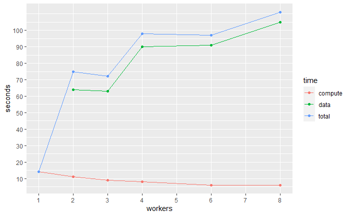

```r
scaling %>%
  ggplot(aes(x = workers, y = seconds, color = time)) +
  geom_line() +
  geom_point() +
  scale_y_continuous(breaks = seq(0, 100, by = 10)) +
  scale_x_continuous(breaks = 1:100, minor_breaks = NULL)
```

The data processing time increases approximately linearly and the compute time decreases logarithmically with the number of cores. The fixed overhead doesn’t look worth it for a smaller dataset like mine.